# Lab 4: Building an Image Classifier from Scratch

The main goal of this lab is to create an image classifier from scratch using the Keras package. You will create a binary classifier based on an object type of your choice. The classifier will accept images and then predict whether or not a given image contains that object. For example, if you chose your object to be a cat, then the classifier would accept images and predict 1 if it believes there is a cat in the image or a 0 if not.

You will build and train a classifier in two ways:

- first using the original data set that you create, and
- second, using data augmentation techniques.

**Grading:**

50% of the grade will come from error-free code that accomplishes all the steps outlined in the instructions for each part of this lab and written in Python/Keras. The other 50% will come from the comments associated with that code, where the comments explain what the code is doing and why it is important to the overall objective. Thus, comments like "split the data" or "train the model" would receive a grade of 0 as they do not indicate any understanding.

**Research Required:**

To complete this lab successfully you will need to some research. At the very least, you will need to implement the [`ImageDataGenerator` class](https://www.tensorflow.org/api_docs/python/tf/keras/preprocessing/image/ImageDataGenerator) and the [`.flow_from_directory` method](https://www.tensorflow.org/api_docs/python/tf/keras/preprocessing/image/ImageDataGenerator#flow_from_directory).

**What to submit:**

- A copy of this notebook with:
  - Error-free code in Python/Keras
  - All code cells executed and output visible
- Include a zipped file of your images

## Part 1: Prep Work

### Choose an Object

**You may choose any object other than a cat**. Try to think of an object that is readily available for taking pictures and, preferably, outdoors, as that will add to the natural variability to the data.

### Create a Dataset

Take 80 pictures of the chosen object and 80 pictures of other things that are not your object. Each group member should supply a roughly equal number of pictures so as to increase variability in your dataset.

From these 160 images you will create a training set (50 object/50 not object), a validation set (15 object/15 not object), and a test set (15 object/15 not object).

It's best if your dataset is diverse, so take pictures of the chosen **object** with, for example, different lighting, from different angles, different distances from camera, different examples of the same type of object. Similarly for the **not object** images: try to include a variety of objects in different ways.

## Part 2: Using the Original Data

### Dataset Verification

You should verify that the training, validation, and test sets have the correct number of images (the `os` functions should help with this) and that the data is organized in `train`, `validation`, and `test` folders.

```python
#libraries

#This module lets you use functionality of dependant operating system
import os

#pandas is a powerful, flexible and easy module to use open source data analysis and manipulation tool
import pandas as pd

#NumPy is the fundamental package for scientific computing
import numpy as np

#Matplotlib is a library for creating visualizations in Python.
import matplotlib.pyplot as plt

#TensorFlow is an end-to-end open source platform for machine learning.
import tensorflow as tf

from tensorflow.keras.preprocessing.image import ImageDataGenerator
from tensorflow.keras.models import Sequential
from tensorflow.keras.layers import Conv2D, MaxPooling2D
from tensorflow.keras.layers import Activation, Dropout, Flatten, Dense
from tensorflow.keras import backend as K

#Ignore warnings
import warnings
warnings.filterwarnings("ignore")
```

```python
#To get the number of folders in a folder and further number of images inside the folder.

path = ['Data','Data/train','Data/validation','Data/train/apple','Data/train/random','data/validation/apple','data/validation/random','Data/test/test']
for i in path:
    lst = os.listdir(i)
    if '.DS_Store' in lst:
        lst.remove('.DS_Store')
    if i == 'Data':
        print(f'{i} folder has {len(lst)} folders {lst}')
    elif i == 'Data/train':
        print(f'{i} folder has {len(lst)} folders {lst}')
    elif i == 'Data/validation':
        print(f'{i} folder has {len(lst)} folders {lst}')
    else:
        print(f'\n{i} folder has {len(lst)} images')
```

```
Data folder has 3 folders ['test', 'train', 'validation']
Data/train folder has 2 folders ['apple', 'random']
Data/validation folder has 2 folders ['apple', 'random']

Data/train/apple folder has 50 images

Data/train/random folder has 50 images

data/validation/apple folder has 15 images

data/validation/random folder has 15 images

Data/test/test folder has 30 images
```

# Dataset Loading and Processing with Image Data Generators

You should now create image data generators for your training, validation, and test datasets that will allow you to feed them into your model in batches. The images should be resized to 148x148 pixels and scaled so all pixel values are between 0 and 1. You should then use the training data generator to print out some examples of the training images and corresponding labels.

```python
#ImageDataGenerator generates batches of tensor image data with real-time data augmentation.
datagen = ImageDataGenerator(
        rescale=1.0/255.0,
        shear_range=0.2,
        zoom_range=0.2,
        horizontal_flip=True)

# this is the augmentation configuration we will use for testing:
# only rescaling
test_datagen = ImageDataGenerator(rescale=1. / 255)

#storing the size of a image and batch size in a variable
image_size = (148, 148)
batch_size = 32

#calling image_dataset_from_directory(main_directory, labels='inferred') will return a tf.data.Dataset
#that yields batches of images from the subdirectories class_a and class_b, together with labels 0 and 1

train_ds = tf.keras.preprocessing.image_dataset_from_directory(
#path
    "Data/train/",
#Subdirectory classes to be stored as binary number
    label_mode='binary',
#Mode of the picture is set to rgb since it is a colored picture
    color_mode='rgb',
#Seed function is used to save the state of a random function
    seed=42,
#Setting the image size as per instructions
    image_size=image_size,
#Total number of training examples present in a single batch.
    batch_size=batch_size,
#Shuffle the images in the dataset
    shuffle=True,
)

#flow_from_directory() : This method is useful when the images are sorted and placed in there respective
#class/label folders. This automatically detects the folders

valid_generator = test_datagen.flow_from_directory(
#path of the directory
    directory="Data/validation/",
#size of the image as per instructions
    target_size=image_size,
    color_mode="rgb",
    batch_size=batch_size,
    #class_mode="categorical",
#Subdirectory classes to be stored as binary number
    class_mode='binary',
    shuffle=True,
    seed=42
)

test_generator = test_datagen.flow_from_directory(
    directory="Data/test/",
    target_size=image_size,
    color_mode="rgb",
    batch_size=batch_size,
    class_mode="binary",
    shuffle=True,
    seed=42
)
```

```
Found 100 files belonging to 2 classes.
Found 30 images belonging to 2 classes.
Found 30 images belonging to 1 classes.
```

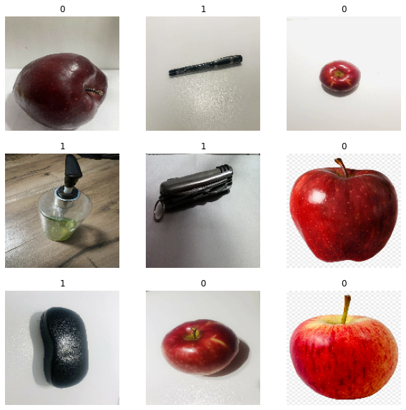

```python
#Plotting the images to visualize the label with respect to the images

plt.figure(figsize=(10, 10))
for images, labels in train_ds.take(1):
    for i in range(9):
        ax = plt.subplot(3, 3, i + 1)
        plt.imshow(images[i].numpy().astype("uint8"))
        plt.title(int(labels[i]))
        plt.axis("off")
```

### Create and Evaluate a Model

Build a convolutional neural network and use the validation loss and accuracy to select the best architecture and hyperparameters so that you can maximize the validation accuracy.

Any overfitting should be addressed; that is, if your model begins overfitting after epoch 3, you should not quote validation accuracy after epoch 15. And, appropriate attempts should be made to reduce/eliminate the overfitting to improve overall model generalizability.

```python
img_width, img_height = 148, 148

#storing the number of images in the variable
nb_train_samples = len(train_ds)
nb_validation_samples = len(valid_generator)
epochs = 5
batch_size = 1

#The image_data_format parameter affects how each of the backends treat the data dimensions
#when working with multi-dimensional convolution layers

if K.image_data_format() == 'channels_first':
    input_shape = (3, img_width, img_height)
else:
    input_shape = (img_width, img_height, 3)

#A Sequential model is appropriate for a plain stack of layers where each layer has exactly one
#input tensor and one output tensor. So it decreases the line of code as well

model = Sequential()

#2D convolution layer: This layer creates a convolution kernel that is convolved with the layer input to produce a
#tensor of outputs.
model.add(Conv2D(32, (3, 3), input_shape=input_shape))

#The rectified linear activation function or ReLU for short is a piecewise linear function that will output the input directly
#if it is positive, otherwise, it will output zero
model.add(Activation('relu'))
#Max pooling is done to in part to help over-fitting.
model.add(MaxPooling2D(pool_size=(2, 2)))

model.add(Conv2D(32, (3, 3)))
model.add(Activation('relu'))
model.add(MaxPooling2D(pool_size=(2, 2)))

model.add(Conv2D(32, (3, 3)))
model.add(Activation('relu'))
model.add(MaxPooling2D(pool_size=(2, 2)))

model.add(Flatten())
model.add(Dense(64))
model.add(Activation('relu'))
#Adding dropout layer to the model to improve performance
model.add(Dropout(0.5))
model.add(Dense(1))

#Used sigmoid activation function which makes our model output to lie between 0 and 1
model.add(Activation('sigmoid'))

model.compile(loss='binary_crossentropy',
              optimizer='adam',
              metrics=['accuracy'])

# this is the augmentation configuration we will use for training

history = model.fit_generator(
    train_ds,
    steps_per_epoch=nb_train_samples // batch_size,
    epochs=epochs,
    validation_data=valid_generator,
    validation_steps=nb_validation_samples // batch_size)

model.save_weights('first_try.h5')
```

### Report Accuracy on Test Set

Your final step is to make predictions using the test set and report the final test set accuracy.

```python
#For predictions, simply used the predict_generator method.
STEP_SIZE_TEST=test_generator.n//30
test_generator.reset()
pred=model.predict_generator(test_generator,
steps=STEP_SIZE_TEST,
verbose=1)
```

```python
predicted_class_indices=np.argmax(pred,axis=1)
```

```python
# Evaluating the model to check the accuracy
_, acc = model.evaluate_generator(test_generator, steps=len(test_generator), verbose=0)
print('> %.3f' % (acc * 100.0))
```

```
> 33.333
```

```python
#Storing the results in predict_result so as to feed the model new dataset and check what the model is predicting for
#the specific pictures

predict_result = model.predict(test_generator, steps=len(test_generator.filenames))
predictions = []
for index, prediction in enumerate(predict_result):
    if predict_result[index] >= 0.5:
        predictions.append('apple')
    else:
        predictions.append('random')
```

```
WARNING:tensorflow:Your input ran out of data; interrupting training. Make sure that your dataset or generator can generate at least `steps_per_epoch * epochs` batches (in this case, 30 batches). You may need to use the repeat() function when building your dataset.
```

```python
#Presenting the predictions by the model

filenames=test_generator.filenames
results=pd.DataFrame({"Filename":filenames,
                      "Predictions":predictions})
# results.to_csv("results.csv",index=False)
results
```

|  | Filename | Predictions |
| --- | --- | --- |
| 0 | test/10.png | random |
| 1 | test/1635099021387.jpg | random |
| 2 | test/1635099021628.jpg | apple |
| 3 | test/1635099021757.jpg | apple |
| 4 | test/1635099021776.jpg | apple |
| 5 | test/1635099021831.jpg | random |
| 6 | test/26.png | apple |
| 7 | test/30.png | apple |
| 8 | test/31.png | apple |
| 9 | test/46.png | random |
| 10 | test/IMG-20211022-WA0097.jpg | apple |
| 11 | test/IMG-20211022-WA0139.jpg | apple |
| 12 | test/IMG_2479.jpg | apple |
| 13 | test/IMG_9621.jpg | apple |
| 14 | test/IMG_9623.jpg | apple |
| 15 | test/IMG_9627.jpg | random |
| 16 | test/IMG_9629.jpg | apple |
| 17 | test/IMG_9635.jpg | random |
| 18 | test/IMG_9637.jpg | apple |
| 19 | test/IMG_9642.jpg | random |
| 20 | test/IMG_9648.jpg | apple |
| 21 | test/IMG_9650.jpg | random |
| 22 | test/IMG_9659.jpg | random |
| 23 | test/IMG_9665.jpg | apple |
| 24 | test/IMG_9681.jpg | apple |
| 25 | test/IMG_9692.jpg | apple |
| 26 | test/IMG_9693.jpg | apple |
| 27 | test/IMG_9694.jpg | apple |
| 28 | test/IMG_9695.jpg | apple |
| 29 | test/IMG_9696.jpg | random |

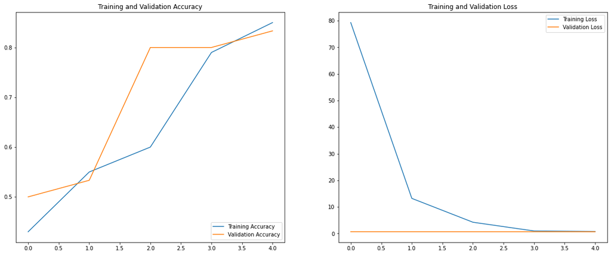

```python
#Visualization will help to give proper insignt of how the model is performing. The below graphs depicts the
#Training Accuracy, Validation Accuracy as well as Training loss and validation loss

acc = history.history['accuracy']
val_acc = history.history['val_accuracy']

loss = history.history['loss']
val_loss = history.history['val_loss']
epochs_range = range(epochs)

#plotting thr visualization
plt.figure(figsize=(20, 8))
plt.subplot(1, 2, 1)
plt.plot(epochs_range, acc, label='Training Accuracy')
plt.plot(epochs_range, val_acc, label='Validation Accuracy')
plt.legend(loc='lower right')
plt.title('Training and Validation Accuracy')

#subplot to show the graphs in single picture
plt.subplot(1, 2, 2)
plt.plot(epochs_range, loss, label='Training Loss')
plt.plot(epochs_range, val_loss, label='Validation Loss')
plt.legend(loc='upper right')
plt.title('Training and Validation Loss')
plt.show()
```

## Part 3: Using Data Augmentation

### Dataset Verification

You should verify that the training, validation, and test sets have the correct number of images (the `os` functions should help with this) and that the data is organized in a folder structure that will work with your image data generators.

```python
path = ['Data','Data/train','Data/validation','Data/train/apple','Data/train/random','data/validation/apple','data/validation/random','Data/test/test']
for i in path:
    lst = os.listdir(i)
    if '.DS_Store' in lst:
        lst.remove('.DS_Store')
    if i == 'Data':
        print(f'{i} folder has {len(lst)} folders {lst}')
    elif i == 'Data/train':
        print(f'{i} folder has {len(lst)} folders {lst}')
    elif i == 'Data/validation':
        print(f'{i} folder has {len(lst)} folders {lst}')
    else:
        print(f'\n{i} folder has {len(lst)} images')
```

```
Data folder has 3 folders ['test', 'train', 'validation']
Data/train folder has 2 folders ['apple', 'random']
Data/validation folder has 2 folders ['apple', 'random']

Data/train/apple folder has 50 images

Data/train/random folder has 50 images

data/validation/apple folder has 15 images

data/validation/random folder has 15 images

Data/test/test folder has 30 images
```

### Dataset Loading and Processing with Create Image Data Generators

You should now create image data generators for your training, validation, and test datasets that will allow you to feed them into your model in batches. The images should be resized to 148x148 pixels and scaled so all pixel values are between 0 and 1.

```python
datagen = ImageDataGenerator(
        rescale=1.0/255.0,
        shear_range=0.2,
        zoom_range=0.2,
        horizontal_flip=True)

# this is the augmentation configuration we will use for testing:
# only rescaling
test_datagen = ImageDataGenerator(rescale=1. / 255)

image_size = (148, 148)
batch_size = 32

train_ds = tf.keras.preprocessing.image_dataset_from_directory(
    "Data/train/",
    label_mode='binary',
    color_mode='rgb',
    seed=42,
    image_size=image_size,
    batch_size=batch_size,
    shuffle=True,
)
valid_generator = test_datagen.flow_from_directory(
    directory="Data/validation/",
    target_size=image_size,
    color_mode="rgb",
    batch_size=batch_size,
    #class_mode="categorical",
    class_mode='binary',
    shuffle=True,
    seed=42
)

test_generator = test_datagen.flow_from_directory(
    #test_data_dir,
    directory="Data/test/",
    target_size=image_size,
    color_mode="rgb",
    batch_size=batch_size,
    class_mode="categorical",
    shuffle=True,
    seed=42
)
```

```
Found 100 files belonging to 2 classes.
Found 30 images belonging to 2 classes.
Found 30 images belonging to 1 classes.
```

### Add Data Augmentation

You should now add data augmentation to your training data generator. All available types of augmentation should be used.

Print an image and examples of the same image augmented in different ways. (The `.load_img()` and [`.flow()` method](https://www.tensorflow.org/api_docs/python/tf/keras/preprocessing/image/ImageDataGenerator#flow) may be helpful here.)

```python
data_augmentation = tf.keras.Sequential(
    [
        tf.keras.layers.RandomFlip("horizontal_and_vertical"),
        tf.keras.layers.RandomRotation(0.2),
        tf.keras.layers.RandomZoom(.5, .2),
        #tf.keras.layers.RandomContrast(0.25)
        #tf.keras.layers.RandomCrop(50,50)
    ]
)
```

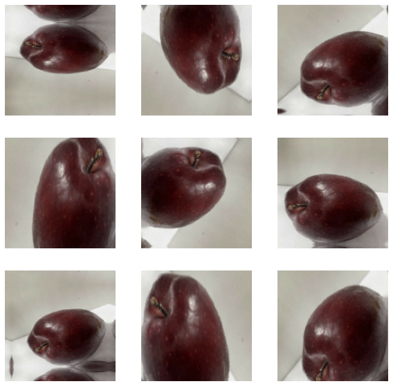

```python
plt.figure(figsize=(10, 10))
for images, _ in train_ds.take(1):
    for i in range(9):
        augmented_images = data_augmentation(images)
        ax = plt.subplot(3, 3, i + 1)
        plt.imshow(augmented_images[0].numpy().astype("uint8"))
        plt.axis("off")
```

```python
inputs = tf.keras.Input(shape=input_shape)
x = data_augmentation(inputs)
x = tf.keras.layers.Rescaling(1./255)(x)
```

### Tune the Model

With a more complex training set, you may be able to improve the accuracy through adjustments to the baseline model architecture and tuning the hyperparameters.

```python
img_width, img_height = 148, 148

nb_train_samples = len(train_ds)
nb_validation_samples = len(valid_generator)
epochs = 10
batch_size = 1

if K.image_data_format() == 'channels_first':
    input_shape = (3, img_width, img_height)
else:
    input_shape = (img_width, img_height, 3)


#model = Sequential()
data_augmentation.add(Conv2D(32, (3, 3), input_shape=input_shape))
data_augmentation.add(Activation('relu'))
data_augmentation.add(MaxPooling2D(pool_size=(2, 2)))

data_augmentation.add(Conv2D(32, (3, 3)))
data_augmentation.add(Activation('relu'))
data_augmentation.add(MaxPooling2D(pool_size=(2, 2)))

data_augmentation.add(Conv2D(128, (3, 3)))
data_augmentation.add(Activation('relu'))
data_augmentation.add(MaxPooling2D(pool_size=(2, 2)))

data_augmentation.add(Flatten())
data_augmentation.add(Dense(128))
data_augmentation.add(Activation('relu'))
data_augmentation.add(Dropout(0.5))
data_augmentation.add(Dense(1))
data_augmentation.add(Activation('sigmoid'))

data_augmentation.compile(loss='binary_crossentropy',
              optimizer='adam',
              metrics=['accuracy'])

# this is the augmentation configuration we will use for training

history_2 = data_augmentation.fit_generator(
    train_ds,
    steps_per_epoch=nb_train_samples // batch_size,
    epochs=epochs,
    validation_data=valid_generator,
    validation_steps=nb_validation_samples // batch_size)

data_augmentation.save_weights('second_try.h5')
```

### Report Accuracy on Test Set

Your final step is to make predictions using the test set and report the final test set accuracy.

```python
STEP_SIZE_TEST=test_generator.n//30
test_generator.reset()
pred=model.predict_generator(test_generator,
steps=STEP_SIZE_TEST,
verbose=1)
```

```python
predicted_class_indices=np.argmax(pred,axis=1)
```

```python
# evaluate model
_, acc = data_augmentation.evaluate_generator(test_generator, steps=len(test_generator), verbose=0)
print('> %.3f' % (acc * 100.0))
```

```
> 60.000
```

```python
predict_result = data_augmentation.predict(test_generator, steps=len(test_generator.filenames))
predictions = []
for index, prediction in enumerate(predict_result):
    if predict_result[index] >= 0.5:
        predictions.append('apple')
    else:
        predictions.append('random')
    #predictions.append([prediction[0]])
```

```
WARNING:tensorflow:Your input ran out of data; interrupting training. Make sure that your dataset or generator can generate at least `steps_per_epoch * epochs` batches (in this case, 30 batches). You may need to use the repeat() function when building your dataset.
```

```python
filenames=test_generator.filenames
results=pd.DataFrame({"Filename":filenames,
                      "Predictions":predictions})
# results.to_csv("results.csv",index=False)
results
```

|  | Filename | Predictions |
| --- | --- | --- |
| 0 | test/10.png | random |
| 1 | test/1635099021387.jpg | random |
| 2 | test/1635099021628.jpg | apple |
| 3 | test/1635099021757.jpg | apple |
| 4 | test/1635099021776.jpg | random |
| 5 | test/1635099021831.jpg | random |
| 6 | test/26.png | apple |
| 7 | test/30.png | apple |
| 8 | test/31.png | random |
| 9 | test/46.png | random |
| 10 | test/IMG-20211022-WA0097.jpg | apple |
| 11 | test/IMG-20211022-WA0139.jpg | apple |
| 12 | test/IMG_2479.jpg | apple |
| 13 | test/IMG_9621.jpg | apple |
| 14 | test/IMG_9623.jpg | apple |
| 15 | test/IMG_9627.jpg | random |
| 16 | test/IMG_9629.jpg | apple |
| 17 | test/IMG_9635.jpg | random |
| 18 | test/IMG_9637.jpg | apple |
| 19 | test/IMG_9642.jpg | random |
| 20 | test/IMG_9648.jpg | apple |
| 21 | test/IMG_9650.jpg | random |
| 22 | test/IMG_9659.jpg | random |
| 23 | test/IMG_9665.jpg | apple |
| 24 | test/IMG_9681.jpg | apple |
| 25 | test/IMG_9692.jpg | apple |
| 26 | test/IMG_9693.jpg | apple |
| 27 | test/IMG_9694.jpg | apple |
| 28 | test/IMG_9695.jpg | apple |
| 29 | test/IMG_9696.jpg | random |

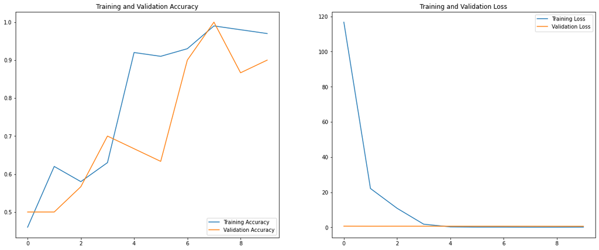

```python
#visualizing
acc = history_2.history['accuracy']
val_acc = history_2.history['val_accuracy']

loss = history_2.history['loss']
val_loss = history_2.history['val_loss']

epochs_range = range(epochs)

plt.figure(figsize=(20, 8))
plt.subplot(1, 2, 1)
plt.plot(epochs_range, acc, label='Training Accuracy')
plt.plot(epochs_range, val_acc, label='Validation Accuracy')
plt.legend(loc='lower right')
plt.title('Training and Validation Accuracy')

plt.subplot(1, 2, 2)
plt.plot(epochs_range, loss, label='Training Loss')
plt.plot(epochs_range, val_loss, label='Validation Loss')
plt.legend(loc='upper right')
plt.title('Training and Validation Loss')
plt.show()
```